# Лабораторная работа №2. Задачи:Основные модели

Имитационное моделирование

Баптишта Матеуж

Группа НФИбд-01-23

Российский университет дружбы народов, Москва, Россия

06 марта 2026

# Информация

## Докладчик

- Баптишта Матеуж
- Студентка 3го курса, группа НФИбд-01-23
- Фундаментальная информатика и информационные технологии
- Российский университет дружбы народов

[figure not shown]

# Вводная часть

# Цель работы

Цель данной лабораторной работы — изучение и численное моделирование днамических систем на примере эпидемиологической модели SIR и модели взаимодействия популяций Лотки-Вольтерры с использованием языка Julia.

# Задание

- Создать рабочий каталог для всего курса. -Установить необходимые пакеты.
- Выполнить предложенный код.
- Преобразовать код в литературный стиль.
- Сгенерировать из литературного кода:
  - чистый код;
  - jupyter notebook;
  - документацию в формате Quarto.
- Выполнить код из jupyter notebook.
- Интегрировать документацию в формате Quarto в отчёт.
- Добавить в код в литературном стиле вычисление для набора параметров.
- Сгенерировать из литературного кода с параметрами:
  - чистый код;
  - jupyter notebook;
  - документацию в формате Quarto.
- Выполнить код из jupyter notebook с параметрами.
- Интегрировать документацию с параметрами в формате Quarto в отчёт.

# Выполнение лабораторной работы

## Создание рабочего каталога курса

[figure not shown]

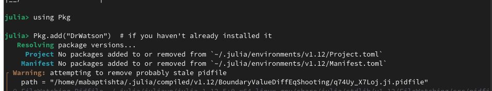

Вставляем код из скрипта ([рис. @fig-003]).

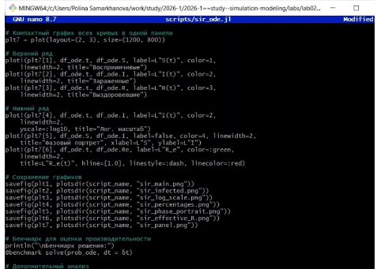

код SIR

Запускаем julia ([рис. @fig-004]).

[figure not shown]

запуск julia

## Установка и настройка необходимых пакетов и ПО

Устанавливаем необходимые пакеты ([рис. @fig-005]).

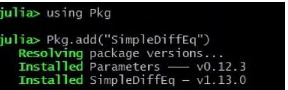

установка пакетов

## Запуск программы

Запускаем программу, получем ответ и диаграммы ([рис. @fig-006]), ([рис. @fig-007]), ([рис. @fig-008]), ([рис. @fig-009]), ([рис. @fig-010]), ([рис. @fig-011]), ([рис. @fig-012]).

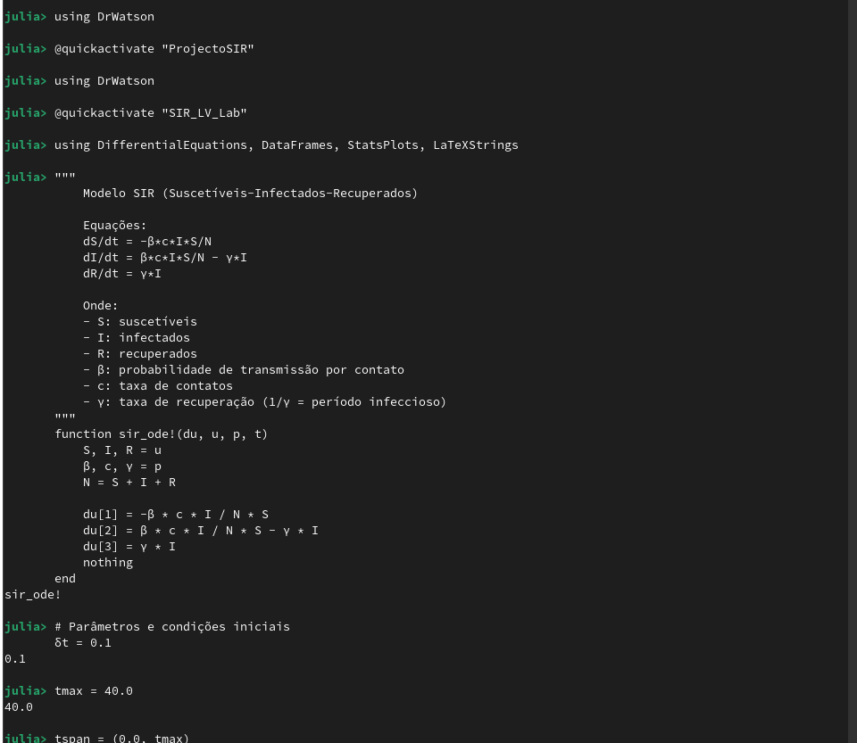

запуск

[figure not shown]

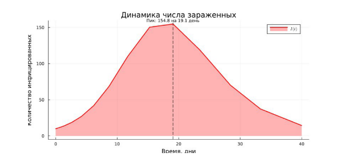

динамика числа зараженных

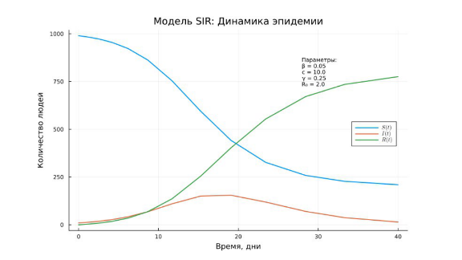

динамика эпидемии

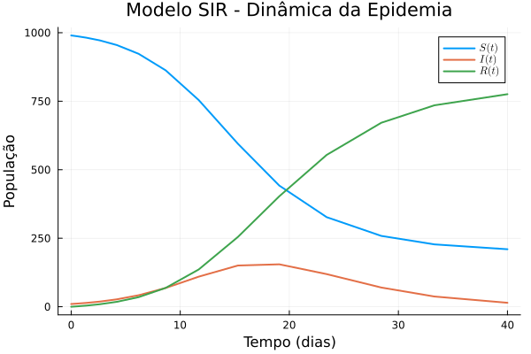

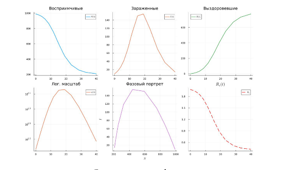

графики

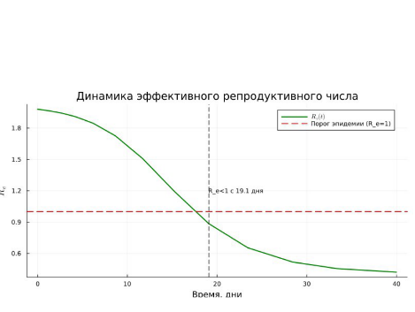

## Проект LV

Создаем папку ПроектLV и переходим в неё ([рис. @fig-013]).

[figure not shown]

папка проекта

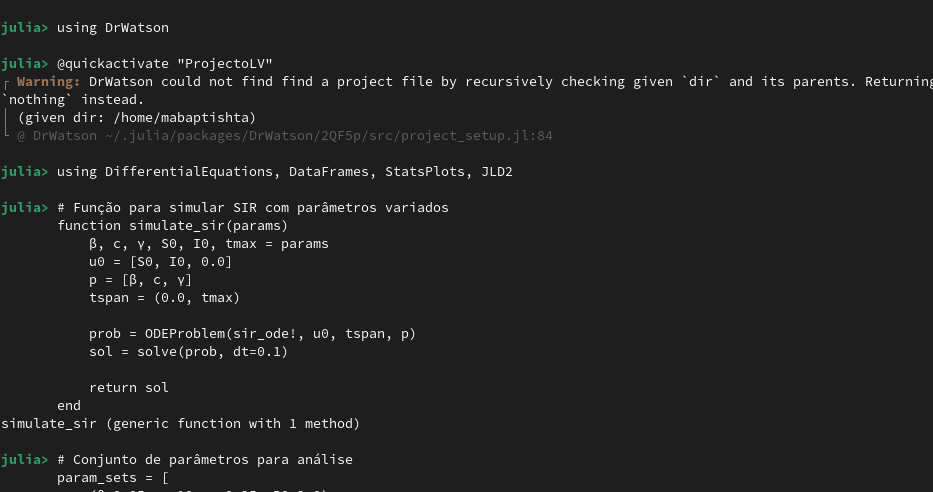

активизация

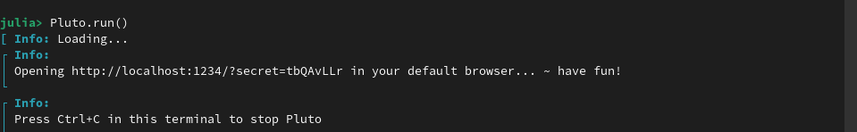

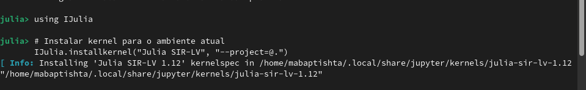

Открываем блокнот и создаем новый файл ([рис. @fig-017]).

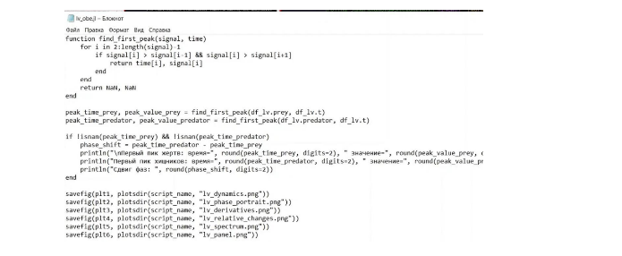

переход в блокнот

[figure not shown]

Запускаем код и смотрим результаты ([рис. @fig-019]), ([рис. @fig-020]), ([рис. @fig-021]), ([рис. @fig-022]), ([рис. @fig-023]), ([рис. @fig-024]).

[figure not shown]

[figure not shown]

графики

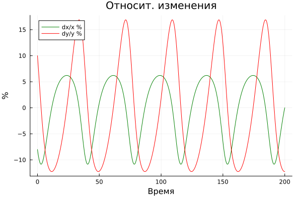

относит. изменения

[figure not shown]

производные

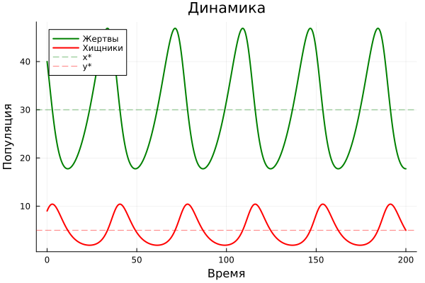

динамика

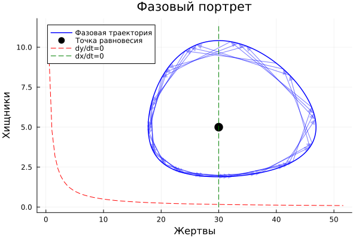

фазовый портрет

# Выводы

В ходе данной лабораторной работы мной были реализованы и проанализированы две модели (SIR / LV). Полученные графики наглядно демонстрируют динамику процессов.